# KEGG analysis of Arabidopsis RNAseq data

M. Naoumkina

2025-11-03

The count data of RNAseq was downloaded from [Expression Atlas web page](https://www.ebi.ac.uk/gxa/experiments/E-GEOD-72806/Downloads)

## 1 Load required packages

```r
#BiocManager::install("clusterProfiler")
#BiocManager::install("pathview")
#BiocManager::install("enrichplot")

library(pathview)
library(clusterProfiler)
library(enrichplot)
library(ggplot2)
```

## 2 Set the desired organism

```r
library(org.At.tair.db)
organism <- "org.At.tair.db"
if (!requireNamespace(organism, quietly = TRUE)) {
  BiocManager::install(organism, character.only = TRUE)}
library(organism, character.only = TRUE)
```

## 3 Prepare Input

```r
# Load saved data DE_res_heat, column name X as gene IDs
df = read.csv("DE_res_heat.csv", header=TRUE)
# we want the log2 fold change
original_gene_list <- df$logFC
# name the vector
names(original_gene_list) <- df$X
# omit any NA values
gene_list<-na.omit(original_gene_list)
# check the gene_list is named numeric vector
str(gene_list)
```

```
##  Named num [1:18983] 9.09 9.24 7.44 -5.48 -3.4 ...
##  - attr(*, "names")= chr [1:18983] "AT3G46230" "AT4G27670" "AT2G29500" "AT2G26560" ...
```

```r
#Filter out non-nuclear genes
gene_list <- gene_list[grep("^AT[1-5]G", names(gene_list))]
# sort the list in decreasing order (required for clusterProfiler)
gene_list = sort(gene_list, decreasing = TRUE)
```

## 4 Convert gene IDs for gseKEGG function

```r
# We will lose some genes here because not all IDs will be converted
ids<-bitr(names(gene_list), fromType = "TAIR", toType = "ENTREZID", OrgDb=organism)
# remove duplicate IDS (here I use "TAIR", but it should be whatever was selected as keyType)
dedup_ids = ids[!duplicated(ids[c("TAIR")]),]

# Create a new dataframe df2 which has only the genes which were successfully mapped using the bitr function above
df2 = df[df$X %in% dedup_ids$TAIR,]

# Create a new column (column Y = ENTREZ) in df2 with the corresponding ENTREZ IDs
df2$Y = dedup_ids$ENTREZID
```

## 5 Create a vector of the kegg gene list

```r
kegg_gene_list <- df2$logFC
# Name vector with ENTREZ ids
names(kegg_gene_list) <- df2$Y
# omit any NA values
kegg_gene_list<-na.omit(kegg_gene_list)
# remove duplicates
kegg_gene_list <- kegg_gene_list[!duplicated(names(kegg_gene_list))]
head(kegg_gene_list)
```

```
##    828881    823768    826616    836093    840477    841789
##  9.094785  9.237678  7.437134 -5.484266 -3.401874 -7.222884
```

```r
any(duplicated(names(kegg_gene_list)))  # should return FALSE
```

```
## [1] FALSE
```

```r
# sort the list in decreasing order (required for clusterProfiler)
kegg_gene_list <- sort(kegg_gene_list, decreasing = TRUE)
```

## 6 Create gseKEGG object

KEGG Organism Code. For Arabidopsis the code is ‘ath’. The full list of organisms codes is [here](https://www.genome.jp/kegg/catalog/org_list.html).

- I define this as kegg_organism first, because it is used again below when making the pathview plots.
- nPerm the higher the number of permutations you set, the more accurate your result will, but the longer the analysis will take.
- minGSSize minimum number of genes in set (gene sets with lower than this many genes in your dataset will be ignored).
- maxGSSize maximum number of genes in set (gene sets with greater than this many genes in your dataset will be ignored).
- pvalueCutoff pvalue Cutoff.
- pAdjustMethod one of “holm”, “hochberg”, “hommel”, “bonferroni”, “BH”, “BY”, “fdr”, “none”.
- keyType one of ‘kegg’, ‘ncbi-geneid’, ‘ncib-proteinid’ or ‘uniprot’.

```r
kegg_organism = "ath"
kk2 <- gseKEGG(geneList     = kegg_gene_list,
               organism     = kegg_organism,
               nPerm        = 10000,
               minGSSize    = 3,
               maxGSSize    = 800,
               pvalueCutoff = 0.05,
               pAdjustMethod = "none",
               keyType       = "ncbi-geneid")

#To evaluate kk2 object
head(as.data.frame(kk2), 10)
```

```
##                ID                                   Description setSize
## ath00750 ath00750                         Vitamin B6 metabolism      15
## ath04141 ath04141   Protein processing in endoplasmic reticulum     190
## ath00051 ath00051               Fructose and mannose metabolism      51
## ath00909 ath00909 Sesquiterpenoid and triterpenoid biosynthesis      14
## ath00310 ath00310                            Lysine degradation      30
## ath00480 ath00480                        Glutathione metabolism      84
##          enrichmentScore       NES      pvalue    p.adjust    qvalue rank
## ath00750       0.6994297  1.845671 0.002915452 0.002915452 0.4431487 1030
## ath04141       0.3249057  1.418403 0.007045675 0.007045675 0.5354713 1041
## ath00051       0.4442026  1.561595 0.014990224 0.014990224 0.6936451 3570
## ath00909      -0.6459687 -1.628273 0.020668341 0.020668341 0.6936451 1389
## ath00310      -0.5135185 -1.570521 0.022817273 0.022817273 0.6936451 3104
## ath00480       0.3523159  1.364447 0.043147776 0.043147776 1.0000000 3147
##                            leading_edge
## ath00750  tags=40%, list=6%, signal=38%
## ath04141  tags=12%, list=6%, signal=12%
## ath00051 tags=29%, list=19%, signal=24%
## ath00909  tags=36%, list=8%, signal=33%
## ath00310 tags=23%, list=17%, signal=19%
## ath00480 tags=20%, list=17%, signal=17%
##                                                                                                                                                           core_enrichment
## ath00750                                                                                                                        820850/843632/838347/835061/819270/835440
## ath04141 823768/828881/835218/826616/835341/838604/831076/833746/821720/820438/824489/839355/828520/827367/832950/820016/836301/819968/833459/842728/837562/830625/829402
## ath00051                                                         829180/834832/835871/816652/843027/839444/816672/826805/836279/821543/814643/818220/831699/816505/828758
## ath00909                                                                                                                               842213/826958/844234/832482/832480
## ath00310                                                                                                                 831244/817892/818083/828165/841849/829452/816300
## ath00480                                           820121/838544/835392/817498/817494/841805/837576/831798/837575/829652/842261/831532/817496/843799/817495/821937/842893
```

## 7 Dotplot with forced one-line pathway labels

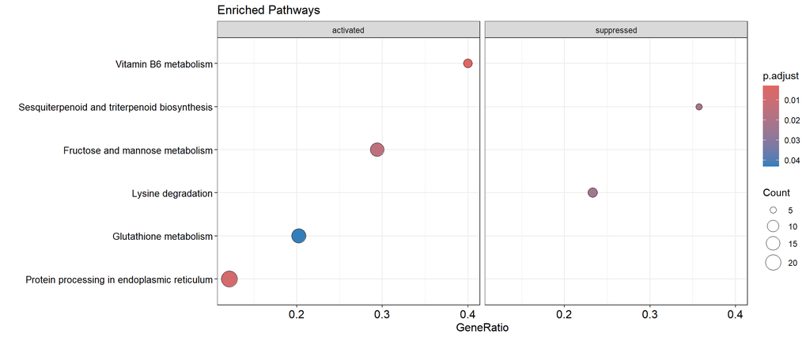

```r
library(stringr)  # for str_wrap
dotplot(kk2, showCategory = 10, title = "Enriched Pathways" , split=".sign") + facet_grid(.~.sign) + theme(
  axis.text.y = element_text(size = 10),
  plot.margin = margin(5, 5, 5, 20, "pt")
) +
  scale_y_discrete(labels = function(x) str_wrap(x, width = 400))
```

## 8 Encrichment map

```r
# check number of enrichment terms
nrow(kk2@result)
```

```
## [1] 6
```

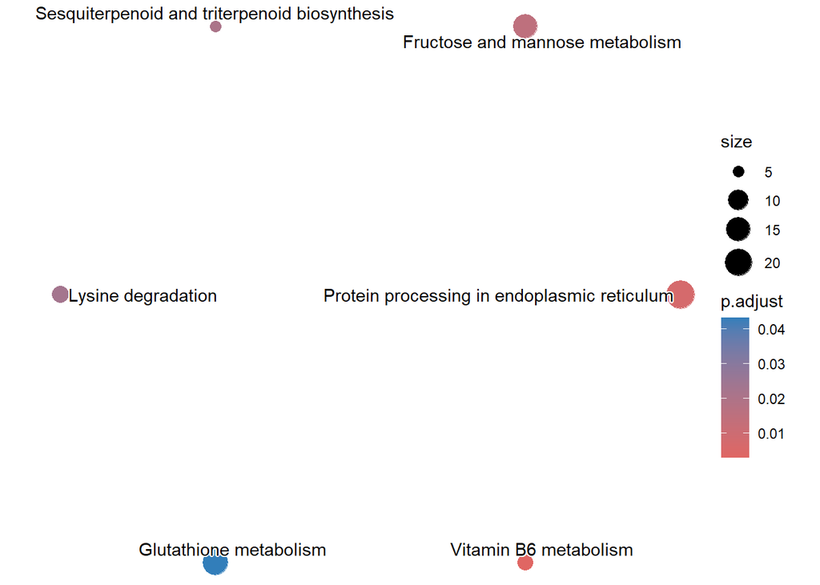

```r
# Compute Term Similarity Explicitly
kk2 <- pairwise_termsim(kk2)
# run emapplot
emapplot(kk2, showCategory = 20)
```

## 9 Category Netplot

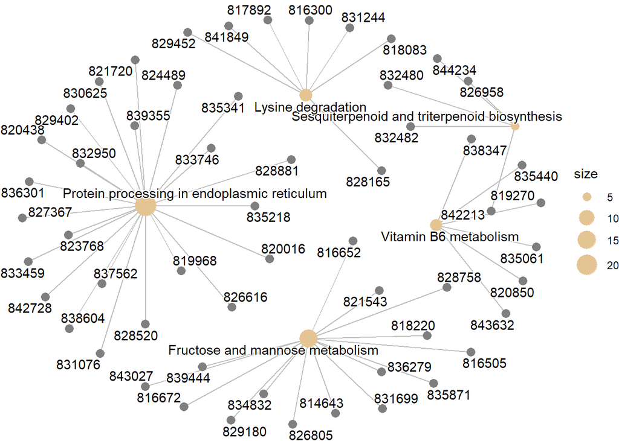

```r
# categorySize can be either 'pvalue' or 'geneNum'
cnetplot(kk2, categorySize="pvalue", foldChange=gene_list)
```

## 10 Ridgeplot with forced one-line pathway labels

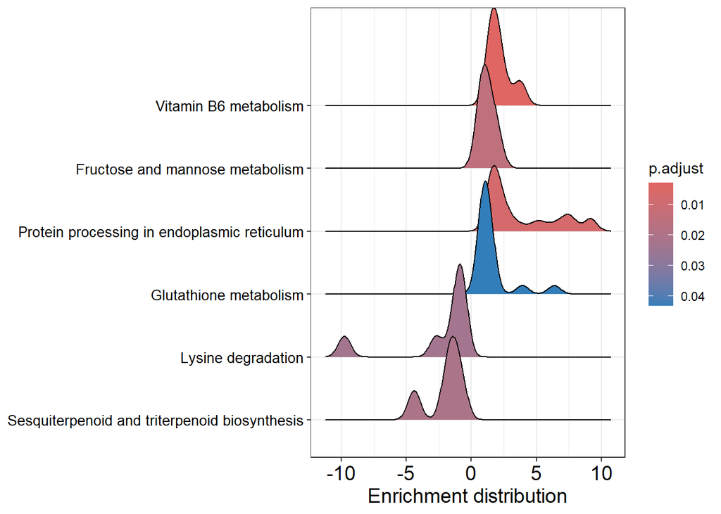

```r
library(stringr)  # for str_wrap
ridgeplot(kk2) +
  labs(x = "Enrichment distribution") +
  theme(axis.text.y = element_text(size = 10)) +
  scale_y_discrete(labels = function(x) str_wrap(x, width = 400))
```

## 11 GSEA Plot

Gene Set Integer corresponds to gene set in the GSE object. The first gene set is 1, second gene set is 2, etc. Default: 1 Use the `Gene Set` param for the index in the title, and as the value for `geneSetId`.

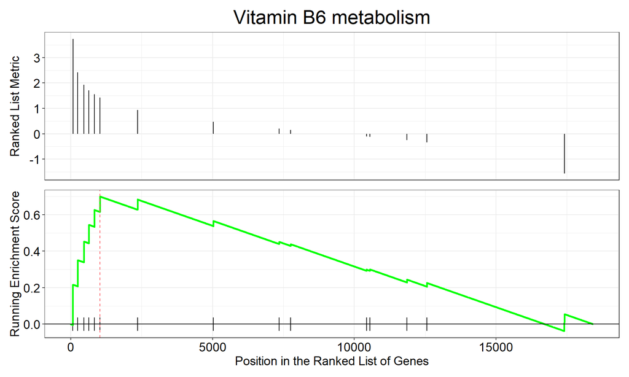

```r
gseaplot(kk2, by = "all", title = kk2$Description[1], geneSetID = 1)
```

## 12 Pathview

Following parameters are needed to be enter: `gene.data` is the kegg_gene_list created above; `pathway.id`, which cab be found in the gseKEGG output table; `species` same as organism above in gseKEGG, which we defined as kegg_organism.

```r
# Check pathway IDs first
kk2@result$ID
```

```
## [1] "ath00750" "ath04141" "ath00051" "ath00909" "ath00310" "ath00480"
```

[figure not shown]

```r
pathview(gene.data = kegg_gene_list,
         pathway.id = "ath00750",
         species = "ath",
         kegg.native = FALSE)

knitr::include_graphics("ath00750.pathview.png")
```

```r
# Save the native KEGG plot (PNG) in your working directory
ath <- pathview(gene.data=kegg_gene_list, pathway.id="ath00750", species = kegg_organism)
```